# ggplot2

Mino

Friday, February 27, 2015

# ggplot2

- Leland Wilkinson의 “The Grammar of Graphics”를 바탕으로 하여 그래프를 그릴 수 있게 한다

## ggplot2의 장점

- 동일한 문법으로 다양한 그래프를 그릴 수 있다.
- 비교적 쉽게 높은 수준의 그래프를 그릴 수 있다.
- 데이터를 다루고 이해하는데 좋다

# Grammar of Graphics

ggplot의 구조를 이해하고 사용할 수 있도록 grammar of graphics에서 제시하는 개념들과 함께 정리해보자

## Plot의 구성요소

- A set of layers
- A set of scales
- A coordinate system
- A facetting specification

### 1. Layers

- Data
- Aesthetic mappings (aes)
- A geometric object (geom)
- A statistical transformation (stat)
- A position adjustment (position)

### 2. Scales

- Scale은 데이터값이 에스테틱에 대입되는 과정을 조절하고 guide(축과 범례 등)가 어떻게 표시될지를 결정한다
- 보통 ggplot이 알아서 scale을 추가하지만, 원하는 사항에 대해서는 명시해주어야 한다.

### 3. Coordinate systems

- 좌표를 결정하는 에스테틱들이 어떻게 연결되는지를 결정한다
- 기본값은 Cartesian 좌표평면이다
- stat과 geom이 반영된 이후에 변경할 수 있다

## how to make a plot?

- length vs width의 산점도(scatter plot)를 그려보자

| length | width | trt |
| --- | --- | --- |
| 2 | 3 | a |
| 1 | 2 | a |
| 4 | 5 | b |
| 9 | 10 | b |

- 산점도(scatter plot)를 그리기 위해 고려해야 할 것은 무엇일까?
  - 값들을 점으로 표현 (geom)
  - 값은 변형없이 그대로 사용 (stat)
  - X, Y축에는 linear scaling (scales)
  - Cartesian 좌표평면 적용
- Mapping
  - length -> `x`
  - width -> `y`
  - trt -> `colour`

| x | y | colour |
| --- | --- | --- |
| 2 | 3 | a |
| 1 | 2 | a |
| 4 | 5 | b |
| 9 | 10 | b |

- Scales
  - 실제로 그래프를 그리는데 사용할 값들로 변경한다

| x | y | colour |
| --- | --- | --- |
| 25 | 11 | red |
| 0 | 0 | red |
| 75 | 53 | blue |
| 200 | 300 | blue |

- Coordinate System

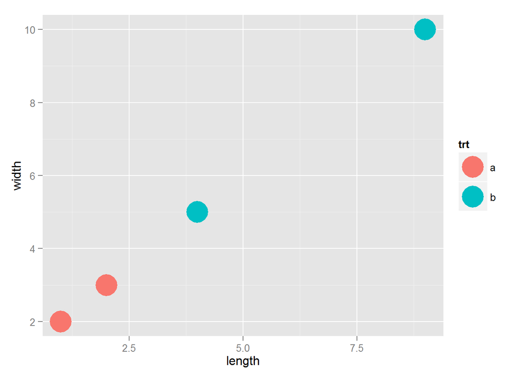

## ggplot2로 그래프를 그리기 위해 필요한 요소

- Data
- Geometric Object (geom)
- Statistical transformation (stat)
- Scales
- Coordinate system
- (Position Adjustment)
- (facetting)

# ggplot2로 그래프 그리기

## Drawing Layers

앞에서 그래프를 그릴때 필요한 요소들을 언급했다.

해당 요소들을 레이어에 대입시켜서 원하는 그래프를 얻을 수 있다

```
## stat_bin: binwidth defaulted to range/30. Use 'binwidth = x' to adjust this.
```

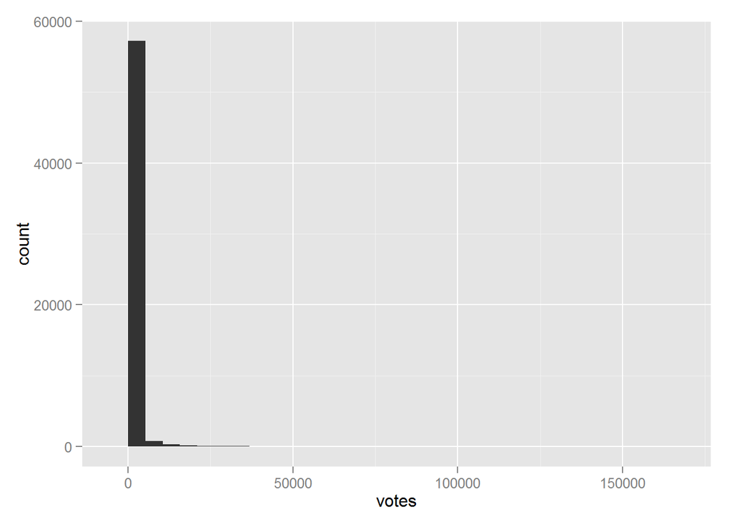

```r
library(ggplot2)
ggplot() +
  layer(data = movies,
        mapping = aes(x=votes),
        geom = "bar",
        stat = "bin",
        position = "identity")
```

## Drawing Layers with short cut

레이어를 이용해서 직접 그리는 것은 명확하지만 코드가 너무 길어지는 경향이 있다.

레이어에 적용될 요소들을 미리 정의해놓은 함수들을 이용해서 그래프를 그릴 수 있다

각 geom들은 기본적으로 반영하는 stat이 정해져있고, stat도 마찬가지이기 때문에 geom과 stat 중 한 가지만 레이어로 그려지면 그래프를 그리는 것이 가능하다

```
## stat_bin: binwidth defaulted to range/30. Use 'binwidth = x' to adjust this.
```

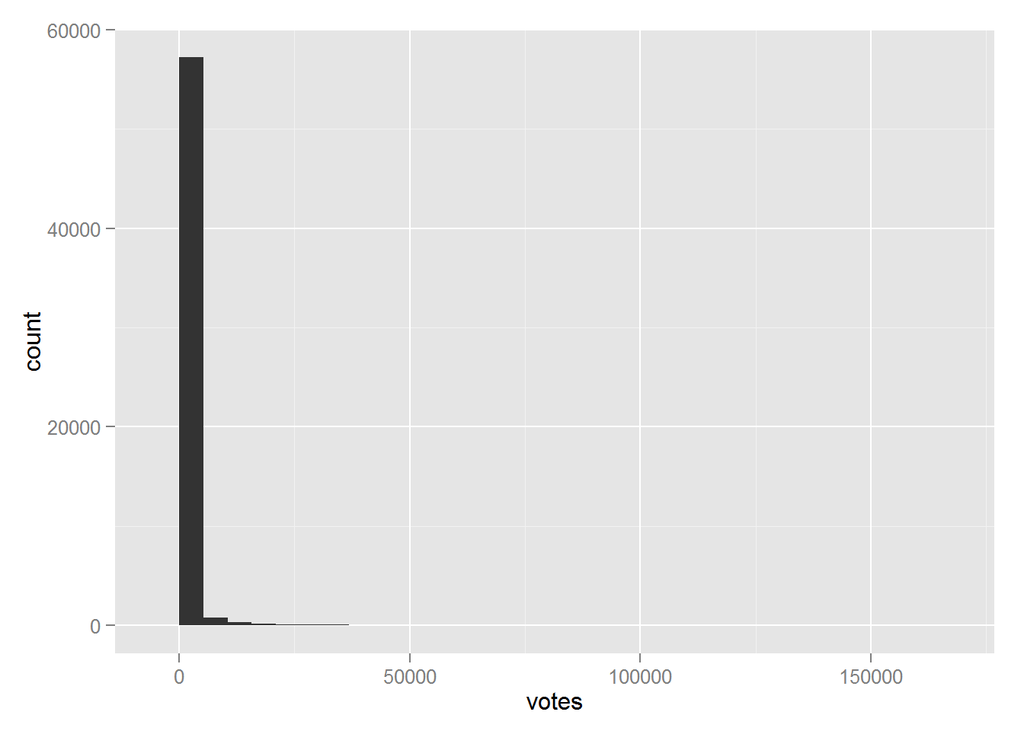

```r
ggplot() +
  geom_bar(data = movies, aes(x=votes))
```

stat의 경우 변환을 통해 geom을 그리는 데 필요한 데이터를 생성한다

`stat_bin`의 경우에는

`count` : 관측값의 개수 (기본적으로 count를 사용)

`density` : 밀도 (전체 합이 1)

`ncount` : [0,1]로 스케일된 count

`ndensity` : [0,1]로 스케일된 ndensity

를 생성하는데

이렇게 생성된 데이터를 그래프에서 사용하려면 `..count..`의 형태로 대입해주면 된다

```
## stat_bin: binwidth defaulted to range/30. Use 'binwidth = x' to adjust this.
```

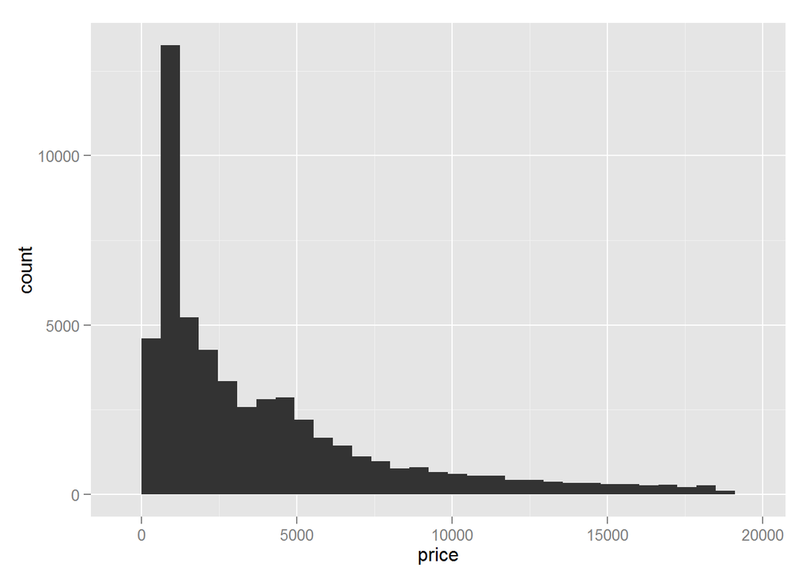

```r
ggplot()+stat_bin(data = diamonds, aes(x= price, y = ..count..))
```

```
## stat_bin: binwidth defaulted to range/30. Use 'binwidth = x' to adjust this.
```

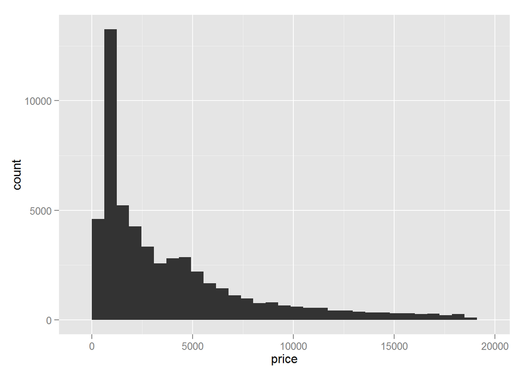

```r
ggplot()+geom_bar(data = diamonds, aes(x= price, y = ..count..))
```

```
## stat_bin: binwidth defaulted to range/30. Use 'binwidth = x' to adjust this.
```

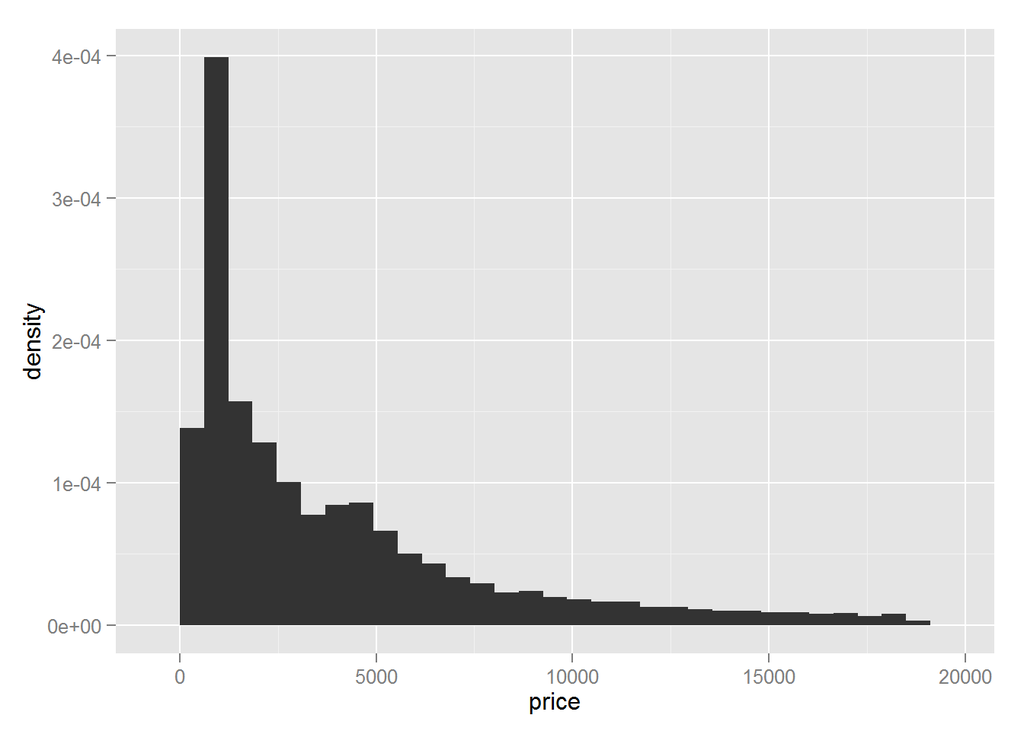

```r
ggplot()+geom_bar(data = diamonds, aes(x= price, y = ..density..))
```

```
## stat_bin: binwidth defaulted to range/30. Use 'binwidth = x' to adjust this.
```

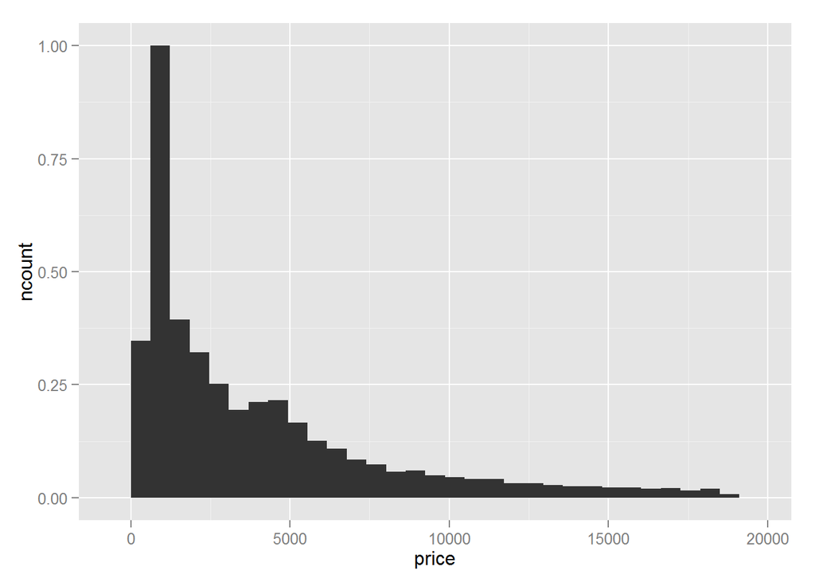

```r
ggplot()+geom_bar(data = diamonds, aes(x= price, y = ..ncount..))
```

```
## stat_bin: binwidth defaulted to range/30. Use 'binwidth = x' to adjust this.
```

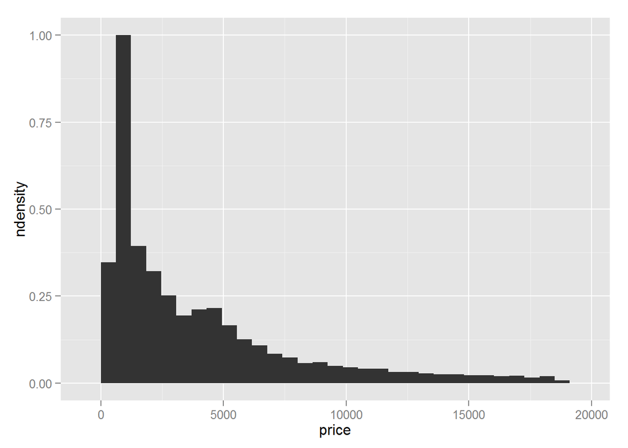

```r
ggplot()+geom_bar(data = diamonds, aes(x= price, y = ..ndensity..))
```

## Multiple Layers

여러개의 레이어를 중첩시켜서 그릴 수 있다

```r
ggplot() +
  geom_point(data = mpg, aes(displ, hwy)) +
  geom_smooth(data = mpg, aes(displ, hwy))
```

[output not shown]

```
## geom_smooth: method="auto" and size of largest group is <1000, so using loess. Use 'method = x' to change the smoothing method.
```

## Avoid redundancy

공통적으로 반영되는 요소들은 미리 정의해두면 geom이나 stat을 추가할 때 자동적으로 상속받게 된다.

추가되는 geom / stat에서 반영되는 요소들은 상속되지 않는다

또, ggplot을 이용해 만든 결과물들은 객체로 저장하는 것이 가능하다

Mapping되는 부분까지만 객체로 저장한 다음에 다양한 시각화를 시도해 볼 수 있다.

```r
ggplot(data = mpg, aes(displ, hwy)) +
  geom_point() +
  geom_smooth()
```

[output not shown]

```
## geom_smooth: method="auto" and size of largest group is <1000, so using loess. Use 'method = x' to change the smoothing method.
```

```r
mpgplot <- ggplot(data = mpg, aes(displ, hwy)) # 객체로 저장
mpgplot +
  geom_point() +
  geom_smooth()
```

[output not shown]

```
## geom_smooth: method="auto" and size of largest group is <1000, so using loess. Use 'method = x' to change the smoothing method.
```

## Adding parameters

- geom의 형태나 stat이 적용되는 방법 등을 변경할 수 있다

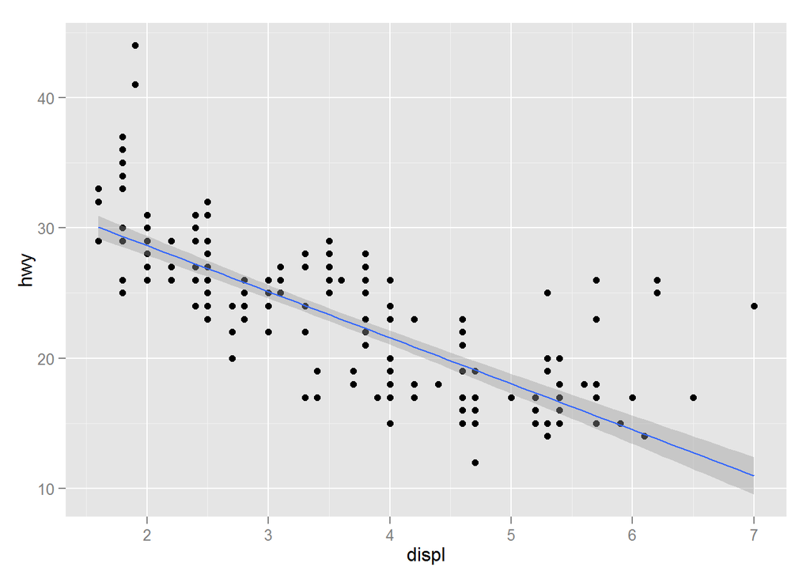

```r
ggplot(data = mpg, aes(displ, hwy)) +
  geom_point() +
  geom_smooth(method = "lm") # 회귀선을 직선으로 명시
```

```
## geom_smooth: method="auto" and size of largest group is <1000, so using loess. Use 'method = x' to change the smoothing method.
```

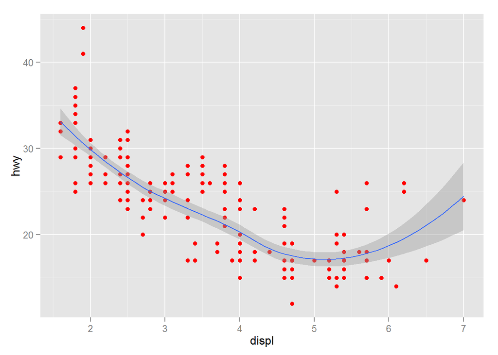

```r
ggplot(data = mpg, aes(displ, hwy)) +
  geom_point(colour = "red") +
  geom_smooth()
```

```
## geom_smooth: method="auto" and size of largest group is <1000, so using loess. Use 'method = x' to change the smoothing method.
```

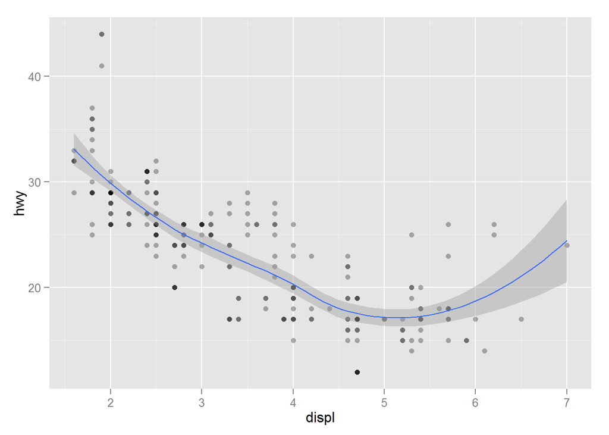

```r
ggplot(data = mpg, aes(displ, hwy)) +
  geom_point(alpha = 0.3) + # 투명도 조절
  geom_smooth()
```

```
## geom_smooth: method="auto" and size of largest group is <1000, so using loess. Use 'method = x' to change the smoothing method.
```

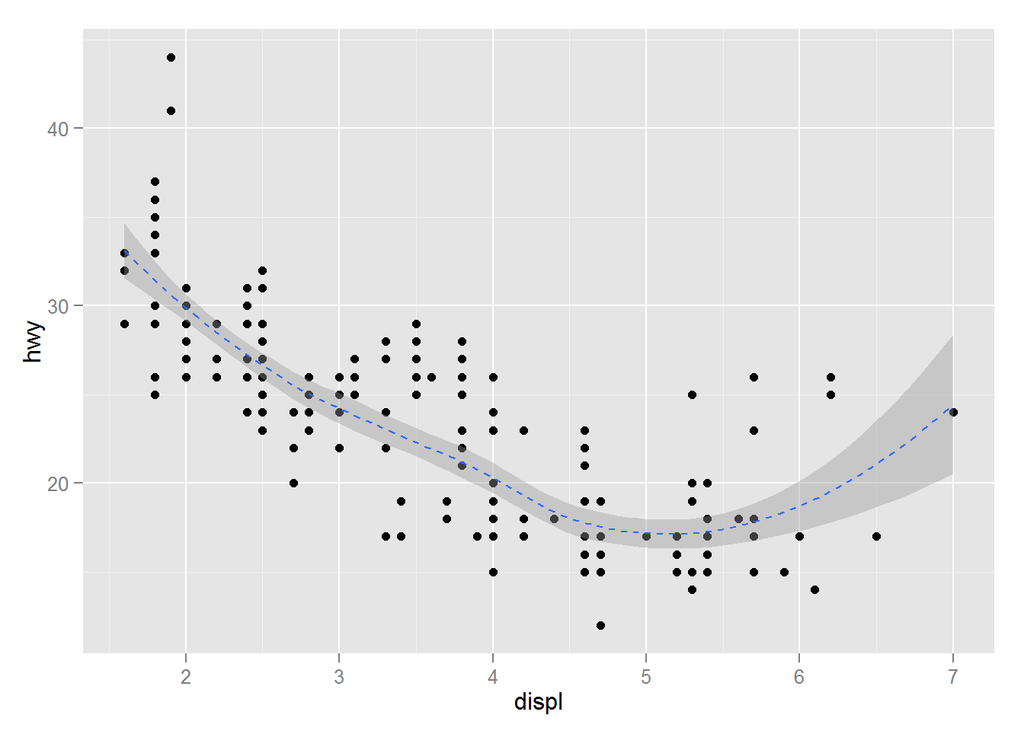

```r
ggplot(data = mpg, aes(displ, hwy)) +
  geom_point() +
  geom_smooth(linetype = 2) # 선 모양 변경
```

```
## geom_smooth: method="auto" and size of largest group is <1000, so using loess. Use 'method = x' to change the smoothing method.
```

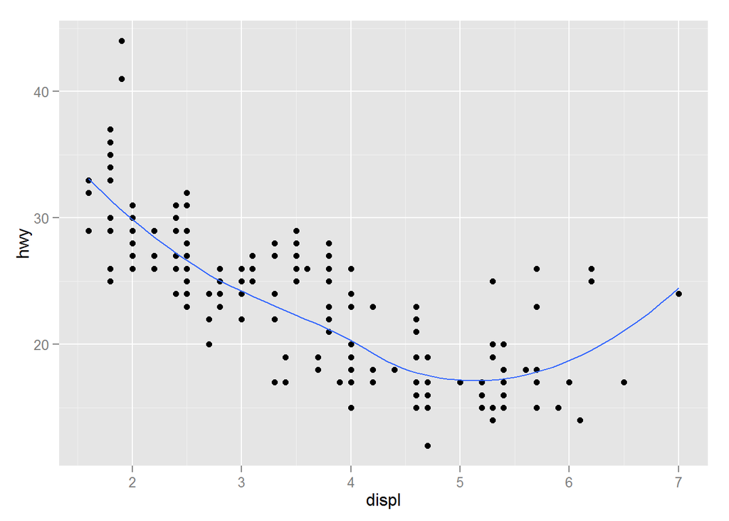

```r
ggplot(data = mpg, aes(displ, hwy)) +
  geom_point() +
  geom_smooth(se = FALSE) # 신뢰구간을 표시하지 않는다
```

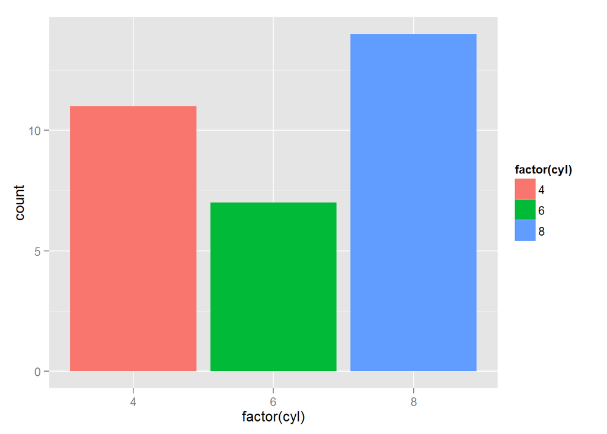

```r
ggplot(mtcars, aes(x=factor(cyl))) +
  geom_bar(aes(fill = factor(cyl))) # fill은 면적에 색을 채운다
```

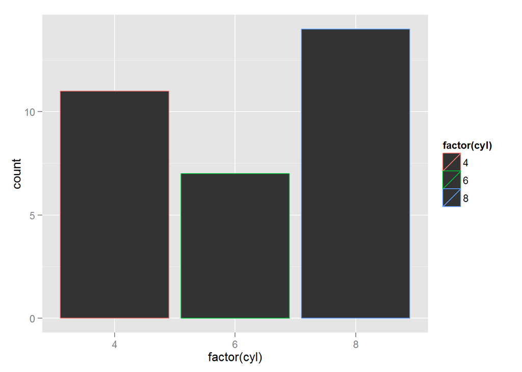

```r
ggplot(mtcars, aes(x=factor(cyl))) +
  geom_bar(aes(colour = factor(cyl))) # colour는 stroke색을 변경
```

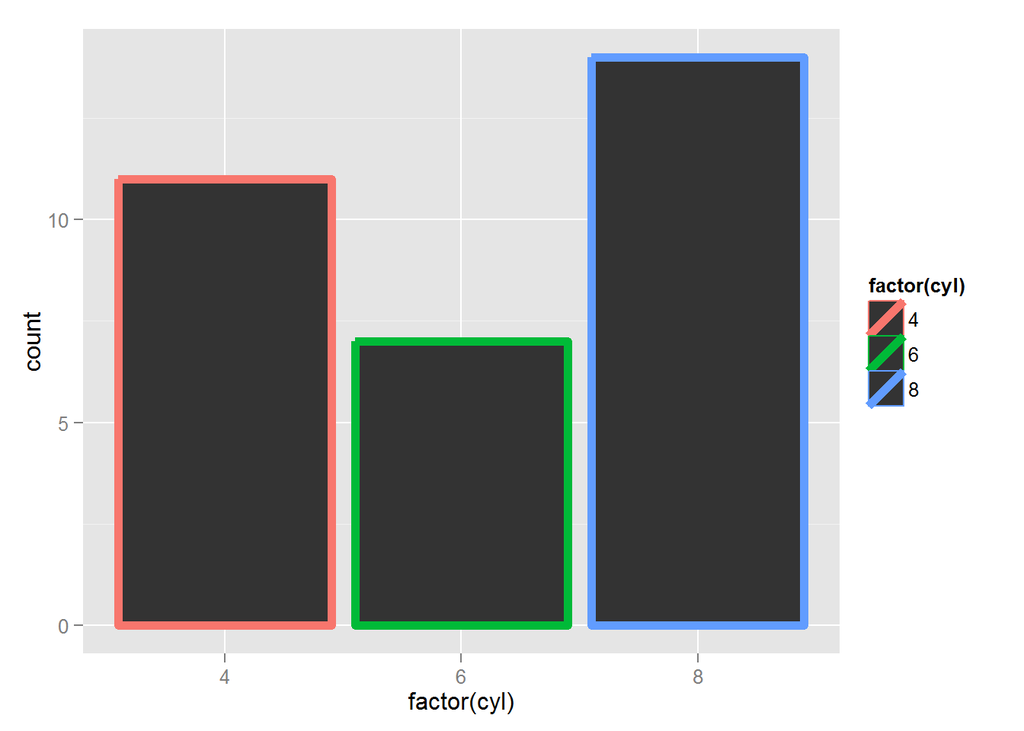

```r
ggplot(mtcars, aes(x=factor(cyl))) +
  geom_bar(aes(colour = factor(cyl)), size = 2)
```

## Position Adjustment

position을 지정하여 geom이 보여지는 형태를 변경할 수 있다

```r
ggplot(data = mpg, aes(displ, hwy)) +
  geom_point() +
  geom_smooth()
```

[output not shown]

```
## geom_smooth: method="auto" and size of largest group is <1000, so using loess. Use 'method = x' to change the smoothing method.
```

```
## geom_smooth: method="auto" and size of largest group is <1000, so using loess. Use 'method = x' to change the smoothing method.
```

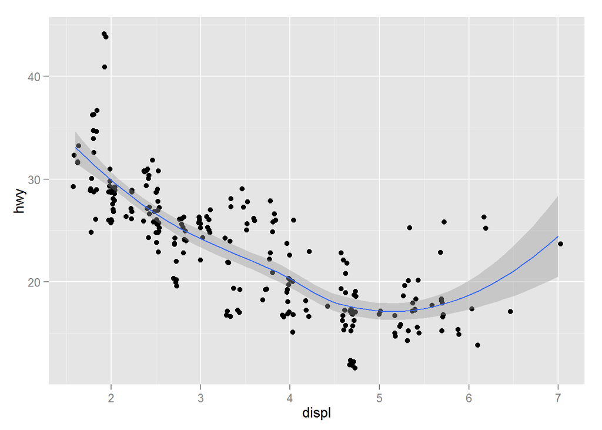

```r
ggplot(data = mpg, aes(displ, hwy)) +
  geom_point(position = "jitter") + # x, y값에 난수를 더해서 점이 겹치지 않게 한다
  geom_smooth()
```

```
## geom_smooth: method="auto" and size of largest group is <1000, so using loess. Use 'method = x' to change the smoothing method.
```

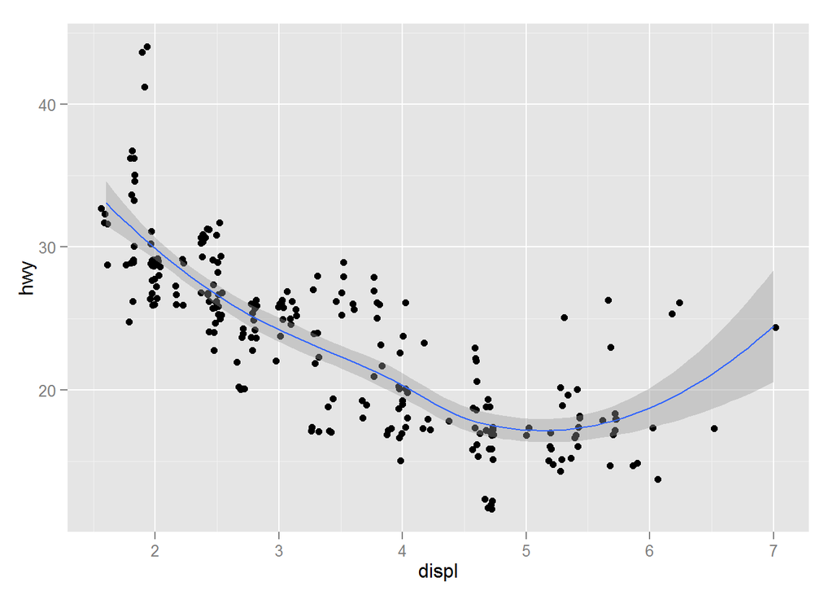

```r
ggplot(data = mpg, aes(displ, hwy)) +
  geom_jitter() + # geom_point(position="jitter")와 같다
  geom_smooth()
```

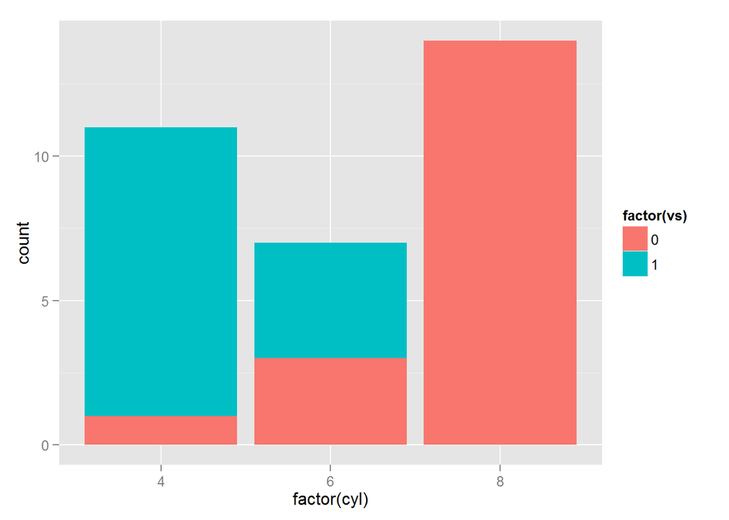

```r
ggplot(mtcars, aes(factor(cyl), fill = factor(vs))) +
  geom_bar()
```

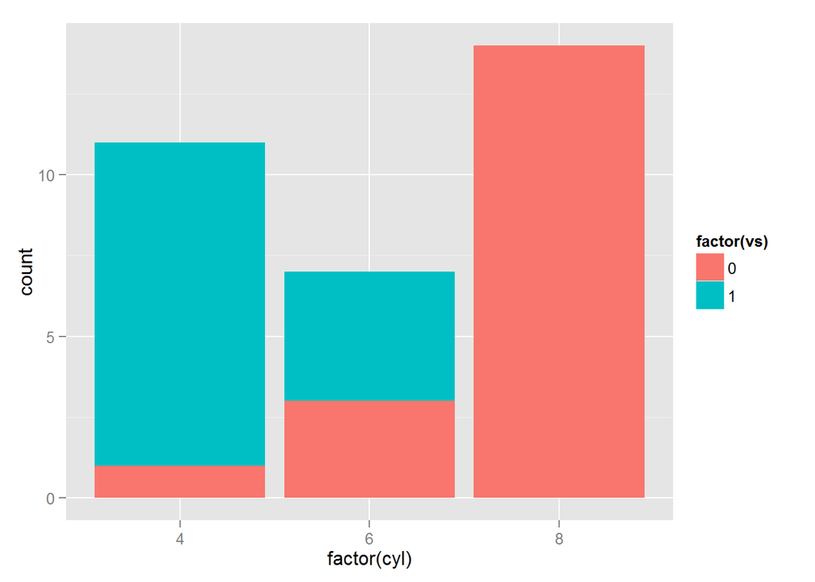

```r
ggplot(mtcars, aes(factor(cyl), fill = factor(vs))) +
  geom_bar(position="stack") # 누적막대
```

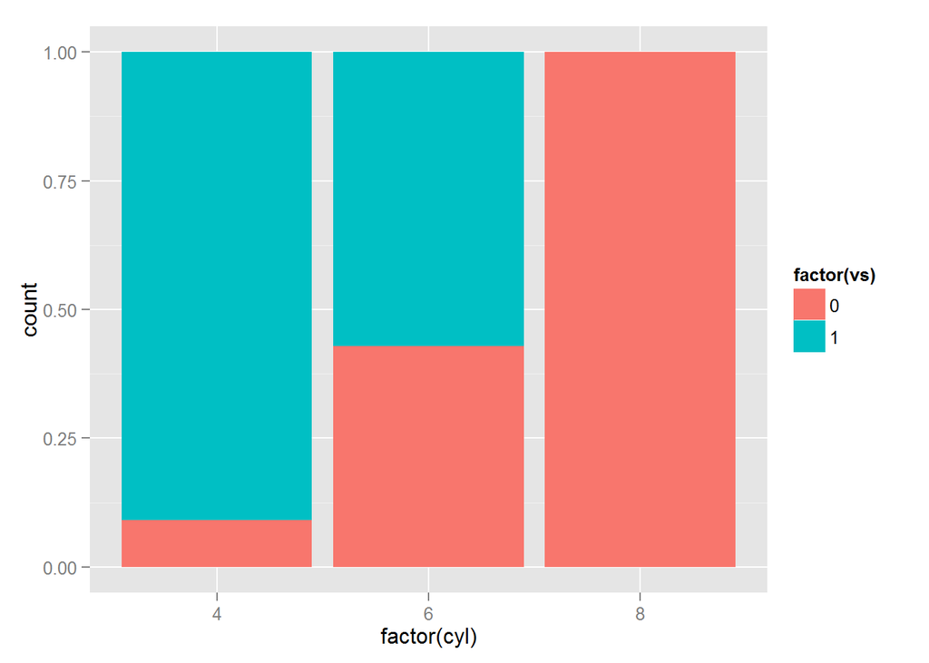

```r
ggplot(mtcars, aes(factor(cyl), fill = factor(vs))) +
  geom_bar(position="fill") # 막대 길이가 일정한 누적막대(%)
```

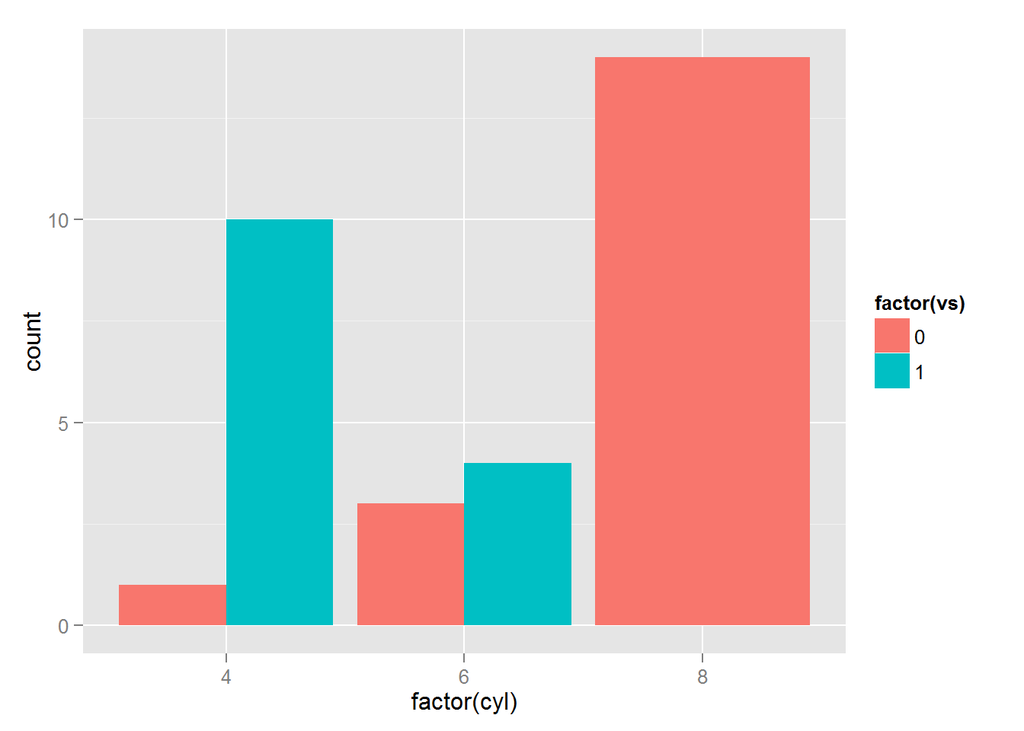

```r
ggplot(mtcars, aes(factor(cyl), fill = factor(vs))) +
  geom_bar(position="dodge") # 각 막대를 옆으로 나열한다
```

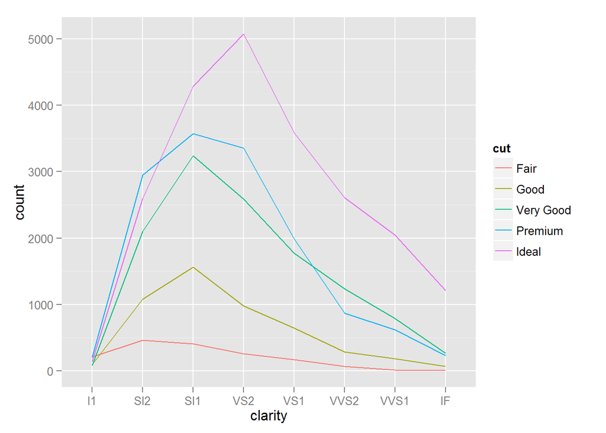

```r
ggplot(diamonds, aes(x=clarity)) +
  geom_freqpoly(aes(group = cut, colour = cut),
                position = "identity") # 값을 그대로 표현
```

```
## ymax not defined: adjusting position using y instead
```

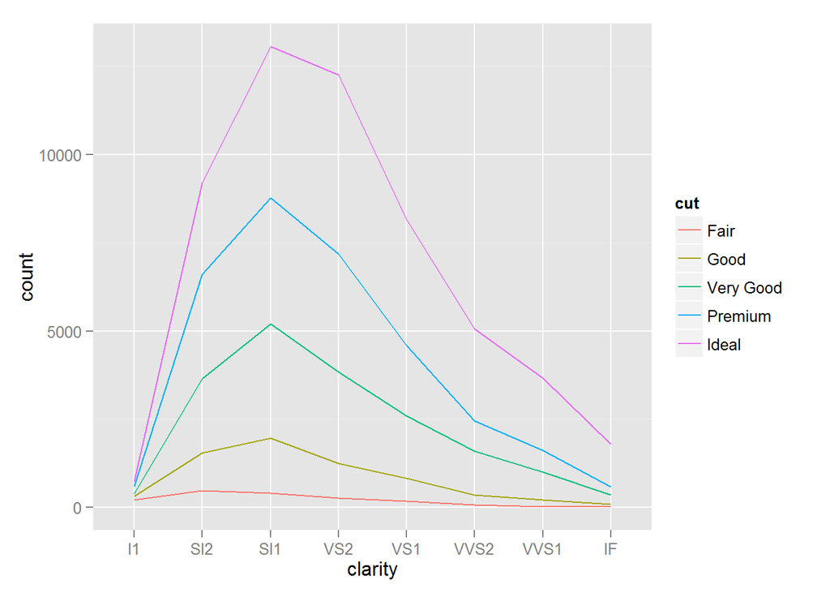

```r
ggplot(diamonds, aes(x=clarity)) +
  geom_freqpoly(aes(group = cut, colour = cut),
                position = "stack") # 누적
```

## Scales

스케일 관련함수는 `scale_에스테틱이름_적용방법`으로 이름이 결정된다

위치 스케일의 경우 `xlim()`과 `ylim()` 함수로 그래프에 표현할 값의 범위를 한정지을 수 있다

```
## geom_smooth: method="auto" and size of largest group is <1000, so using loess. Use 'method = x' to change the smoothing method.
```

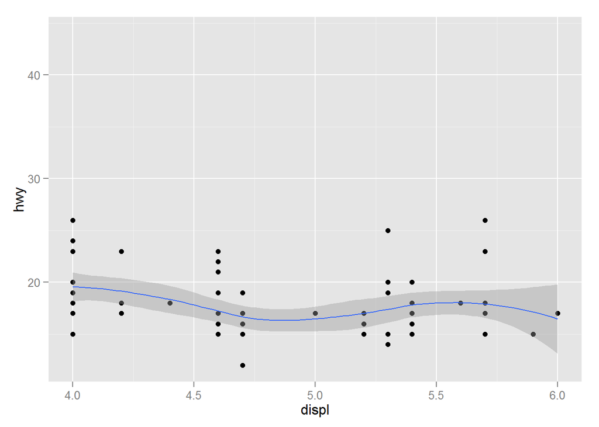

```r
ggplot(data = mpg, aes(displ, hwy)) +
  geom_point() +
  geom_smooth() +
  xlim(4,6)
```

```
## geom_smooth: method="auto" and size of largest group is <1000, so using loess. Use 'method = x' to change the smoothing method.
```

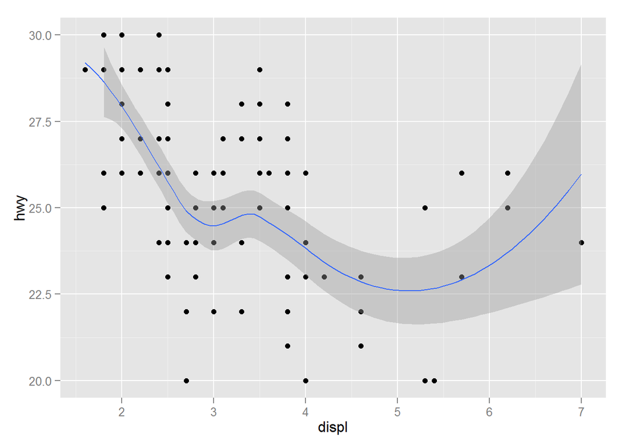

```r
ggplot(data = mpg, aes(displ, hwy)) +
  geom_point() +
  geom_smooth() +
  ylim(20,30)
```

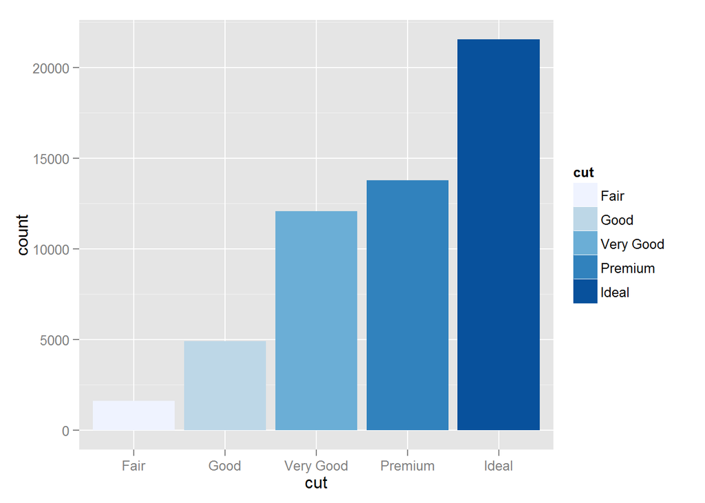

```r
dia_bar <- ggplot(diamonds, aes(x=cut, fill = cut)) + geom_bar()
dia_bar +
  scale_fill_brewer()
```

`RColorBrewer` 패키지를 설치하면 미리 정의된 다양한 색조합을 사용할 수 있다

사용가능한 색 조합의 이름들은 `display.brewer.all()`에서 확인할 수 있다.

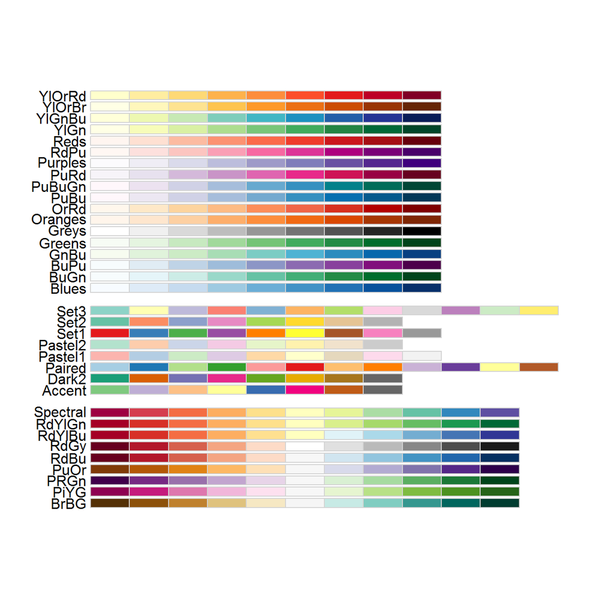

```r
#install.packages("RColorBrewer")
RColorBrewer::display.brewer.all()
```

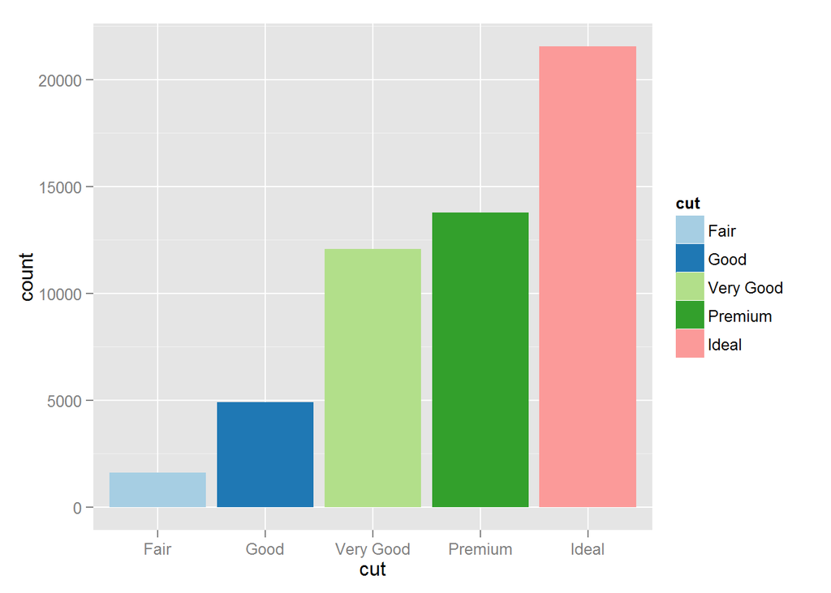

```r
dia_bar +
  scale_fill_brewer(palette = "Paired")
```

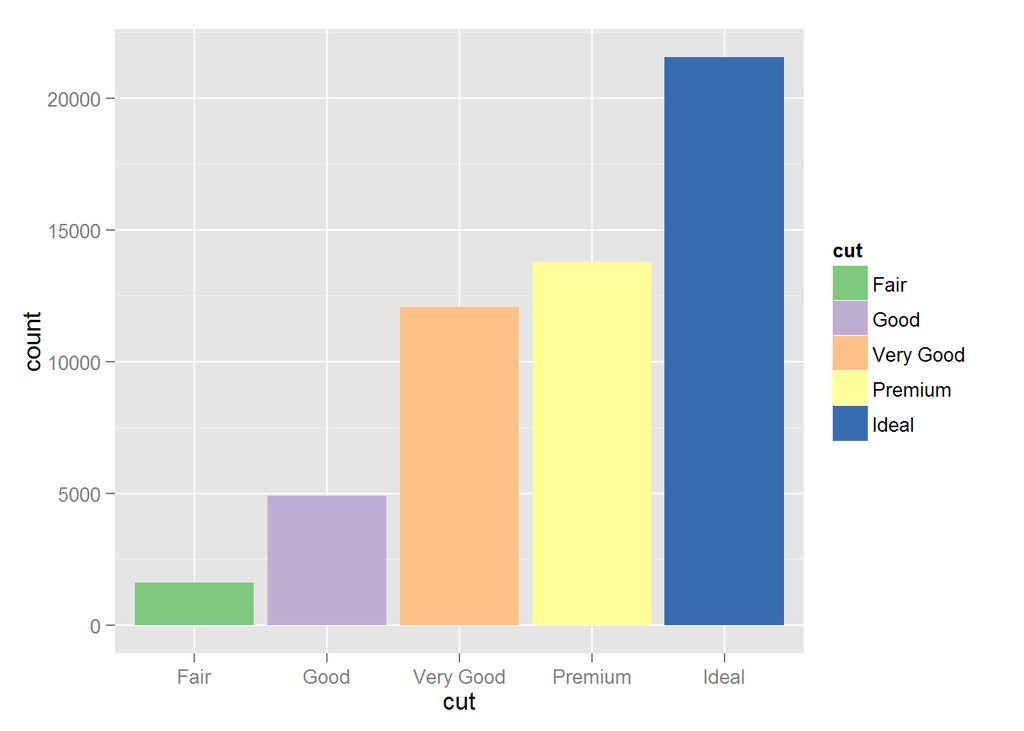

```r
dia_bar +
  scale_fill_brewer(palette = "Accent")
```

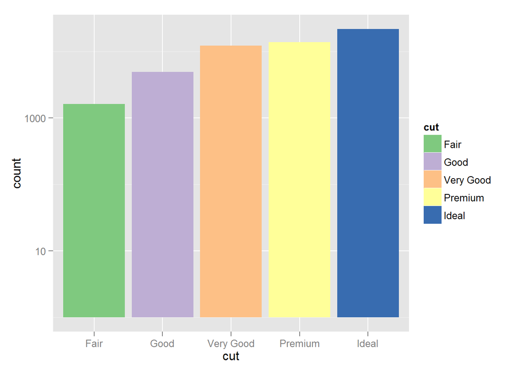

```r
dia_bar +
  scale_fill_brewer(palette = "Accent") +
  scale_y_continuous(trans = "log10") # y축에 log10 함수를 적용
```

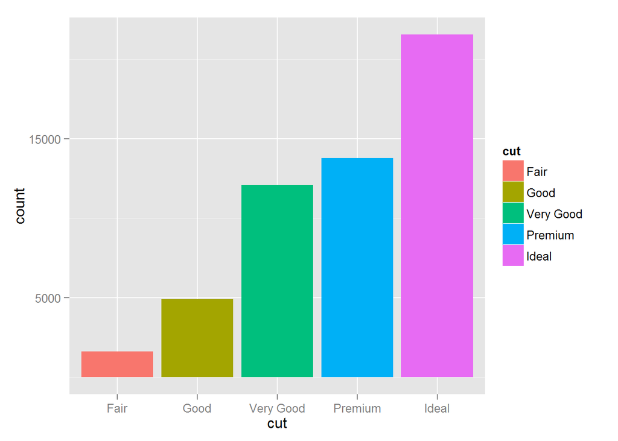

```r
dia_bar +
  scale_y_continuous(breaks = c(5000, 15000)) # 5000, 15000 구간만 표시
```